# MUSA500 - HW1

Chenxi Zhu, Teresa Chang, and Tiffany Luo

2023-11-16

## 1 Introduction

**a)** The majority of pertinent research indicates that the housing value is significantly influenced by factors associated with the property’s location and the characteristics of its neighborhood. The goal of this project is to examine the relationship between median house values in Philadelphia and several neighborhood characteristics, including the percentage of individuals with Bachelor’s degrees or higher, the percentage of vacant houses, the number of households living in poverty, and the percentage of single family housing units.

**b)** To explain why these predictors we’re using might be related with the housing values, we looked at some research papers.

The percentage of vacant houses: Certain recent publications have explored the influence of deteriorated or unoccupied residential structures on property values. For Philadelphia specifically, Shlay and Whitman (2004) have “examined the impact of vacant housing units on nearby home values in Philadelphia and found that properties located within 150 feet of an abandoned unit sold for over $7,000 less than other properties.”$^1$ Therefore, the percentage of vacant houses may have a correlation with the housing values in our project dataset.

The percentage of individuals with Bachelor’s degrees or higher: Generally, the percentage of individuals with Bachelor’s degrees or higher in a neighborhood may influence housing values. This is often associated with a more educated workforce, higher income levels, and a perception of a desirable community. According to a recent study done by Chetty R, Hendren N, Katz LF (2016), households living in neighborhoods with more-educated residents experienced large and persistent increases in neighborhood safety, neighborhood satisfaction, and housing quality.$^2$

The number of households living in poverty: Research conducted by the Urban Institute (2017) suggests a relationship between the number of households living in poverty and housing values. Neighborhoods with higher poverty rates may face challenges related to crime, school quality, and overall community well-being, leading to a decrease in housing values.$^3$

The percentage of single family housing units: The impact of having a higher percentage of single-family housing units on housing values can differ. Sometimes, having more single-family homes can bring stability and boost homeownership, which is good for property values. However, in areas where there’s an overwhelming concentration of single-family houses, it might limit diversity and access to community services, potentially affecting property values negatively.$^4$ Although the research paper suggests two-way relationships, we are interested in examining the case for Philadelphia specifically, in order to see whether the percentage of single family housing units has a correlation with the housing values in the local market.

## 2 Methods

### 2.1 Data Cleaning

To ensure the level of precision, we are using Philadelphia data at the Census block group level. The original Philadelphia block group dataset has 1816 observations. The data is cleaned in advance by removing the following block groups:

1. Block groups where population < 40
2. Block groups where there are no housing units
3. Block groups where the median house value is lower than $10,000
4. One North Philadelphia block group which had a very high median house value (over $800,000) and a very low median household income (less than $8,000)

The final dataset contains 1720 block groups.

### 2.2 Exploratory Data Analysis

As the first step, we should have a basic understanding of our dataset. We will examine the summary statistics of the dependent variable and the predictors, and distributions of variables to examine whether the variables are normally distributed. Then, we will examine the correlations between the predictors. Correlation is a standardized measure of the strength of the relationship between variables. The formula for the sample correlation coefficient r is shown below. In the formula, $n$ represents the number of observations. $x_i$ and $y_i$ are individual data points for variables x and y, respectively. $\bar{x}$ and $\bar{y}$ denote the mean of the x and y variables, respectively. The result ranges from -1 to 1, where -1 indicates a perfect negative linear relationship, all $x_i, y_i$ pairs lie on a straight line with negative slope. r = 1 indicates a perfect positive linear relationship, all $x_i$, $y_i$ pairs lie on a straight line with positive slope. r = 0 indicates a lack of a linear relationship between the variables.

$$r = \frac{\sum_{i=1}^{n}(x_i - \bar{x})(y_i -
\bar{y})}{\sqrt{\sum_{i=1}^{n}(x_i - \bar{x})^2}
\sqrt{\sum_{i=1}^{n}(y_i - \bar{y})^2}}$$

### 2.3 Multiple Regression Analysis

#### 2.3.1 The method of regression

Regression is a statistical method used to examine the relationship between a variable of interest (dependent variable) and one or more explanatory variables (predictors). It can be used to find the strength of the relationship, the direction of the relationship (positive, negative, zero) and the goodness of model fit. Regression allows the user to calculate the amount by which your dependent variable changes when a predictor variable changes by one unit, while holding all other predictors constant. If an explanatory variable is a significant predictor of the dependent variable, it doesn’t imply that the explanatory variable is a cause of the dependent variable. In essence, regression can identify and establish a mathematical equation that best fits the observed data, allowing predictions and explanations of the dependent variable based on the independent variables.

#### 2.3.2 Equation

Our regression equation is:

$$MEDHVAL=β0+β1PCBACHMORE+β2NBELPOV100+β3PCTVACANT+β4PCTSINGLES+ε$$

In this equation, the actual observed value of `MEDHVAL` is a linear function of `PCTVACANT`, `PCTSINGLES`, `PCTBACHMOR`, and `LNNBELPOV1` where `MEDHVAL` represents the median value of all owner occupied housing units, `PCTBACHMOR` refers to the percentage of individuals with Bachelor’s degrees or higher, `PCTVACANT` is the percentage of vacant houses, `LNNBELPOV100` means the number of households with incomes below 100% poverty level, and `PCTSINGLES` denotes the percentage of single family housing units. Every independent variable will be assigned its own slope coefficient `(β1, β2, β3, β4)`, representing the association of that specific predictor with the dependent variable. β0 is the constant term that determines the point at which the regression line intersects the y-axis. The term ε denotes the residual or random error in the model. errors are something that we cannot predict, and are considered to be random. In the absence of ε, every observed pair would precisely align with the true regression line. The introduction of the random error term ε permits the data points to deviate either above the true regression line (when ε > 0) or below the line (when ε < 0).

#### 2.3.3 Regression Assumptions

- Linearity: The first regression assumption is linearity, which assumes that the relationship between the independent variable(s) and the dependent variable is always linear. A change in the independent variables is associated with a constant change in the dependent variable. We’ll use scatter plots of the dependent variable and each of the predictors to check this assumption.
- Independence of observations: The independence of observations assumption in regression means that the values of the dependent variable are unrelated. It means that the dependent variable for one observation should not convey any information about the dependent variable for another observation point.
- Normality of residuals: Normality of residuals is important for point estimation, confidence intervals, and hypothesis tests only for small samples due to the Central Limit Theorem. However, if there are 30+ observations, with 10 additional observations for every additional predictor after the first one, normality of residuals can be less important. Violations of normality of residuals might arise either because the dependent and/or independent variables are themselves non-normal, and/or the linearity assumption is violated. In such cases, a nonlinear transformation of variables might cure both problems. In some cases, the problem with the residual distribution is mainly due to one or two very large errors. If they are merely errors or if they can be explained as unique events not likely to be repeated, then we may have cause to remove them. In some cases, however, it may be that the extreme values in the data provide the most useful information about values of some of the coefficients and/or provide the most realistic guide to the magnitudes of forecast errors. We’ll make a histogram of the standardized residuals to see whether the residuals are normal.
- Homoscedasticity: Homoscedasticity refers to the assumption that the variability of the residuals, which are the differences between observed and predicted values, is constant across all levels of the independent variables. We’ll use the Standardized Residual by Predicted Value scatter plot to check homoscedasticity.
- No multicollinearity: The final assumption is non-multicollinearity. In other words, the predictors should not be very strongly correlated with each other. Multicollinearity is when two or more predictors are very strongly correlated with each other. In other words, it means little or no value will be added when we include a new predictor that’s very similar to a predictor that is already in the model. If multicollinearity is present, we may get unstable regression parameters. Here is a way to test multicollinearity: we’ll use k as the number of predictors (in our case, k equals to 4). Since k>2, it is possible that the pairwise correlations are small, and yet a linear dependence exists among three or even more variables. We can assess for multicollinearity by regressing each predictor k on all the remaining predictors. By looking at the R2 in each of the k regressions, if any of these regressions yield R2 greater than 0.8, there is likely a problem with multicollinearity. Using the R2 values from above, calculate the VIF for each predictor k in the original regression. The VIF for each predictor k is defined as follows: $VIF_k = \frac{1}{1 - R_k^2}$. A VIF of 1 means that there is no correlation among the kth predictor and the remaining predictor variables. VIFs exceeding 4 warrant further investigation, while VIFs exceeding 10 are signs of serious multicollinearity requiring correction.

#### 2.3.4 Parameters Needed to be Estimated

Every independent variable will be assigned its own slope coefficient (β1, β2, β3, β4), representing the association of that specific predictor with the dependent variable while considering the influence of all other independent variables in the regression. β0 is the constant term that determines the point at which the regression line intersects the y-axis.

Given n observations on y, and k predictors $x_0, x_1, x_2, \ldots, x_k$ (in our case, $x_1, x_2, x_3, x_4$), the estimates $\beta_0, \beta_1, \beta_2, \ldots, \beta_k$ are chosen to minimize the expression for the Error Sum of Squares (SSE), given by:

$$SSE = \sum_{i=1}^{n} \varepsilon^2 = \sum_{i=1}^{n} (y - \hat{y})^2 =
\sum_{i=1}^{n} (y_i - \hat{\beta}_0 - \hat{\beta}_1 x_{1i} -
\hat{\beta}_2 x_{2i} - ... - \hat{\beta}_k x_{ki})^2$$

In this equation, $\varepsilon_i$ represents the residual for the $i^{th}$ observation, which is the difference between the actual observed value $y_i$ and the predicted value $\hat{y}_i$ from the regression model. $n$ is the number of observations in the dataset. $\hat{\beta}_0, \hat{\beta}_1, \hat{\beta}_2, \ldots, \hat{\beta}_k$ are the estimated coefficients of the regression model. $x_{1i}, x_{2i}, \ldots, x_{ki}$ are the independent variables for the number i observation.

In Multiple Regression, the variance of the residuals is calculated as $\sigma^2 = \frac{SSE}{n - (k + 1)}$, where k is the number of predictors (in our case, k=4) and n is the number of observations.

#### 2.3.5 The Way of Estimating Parameters

The way to calculate values for β1 and β0 involves minimizing the sum of squared vertical distances (i.e., residuals) between the points and the (estimated) regression line. This way of obtaining parameters is called the least squares principle. The goal in regression analysis is often to minimize SSE (SSE calculates the total of squared variances between the observed values and the predicted values for each data point as previously shown) by choosing the appropriate values for the regression coefficients, because a small SSE means that the model is good at explaining the variability of the dependent variable. The formulas for the slope coefficient and the intercept are:

$$\beta_1 = \frac{\sum_{i=1}^{n} (x_i - \overline{x})(y_i -
\overline{y})}{\sum_{i=1}^{n} (x_i - \overline{x})^2}$$

$$\beta_0 = \overline{y} - \beta_1\overline{x}$$

#### 2.3.5 Coefficient of Multiple Determination $R^2$ and the Adjusted $R^2$

While $R^2$ measures the proportion of the variance in the dependent variable that is explained by the independent variables, adjusted $R^2$ takes into account the number of predictors in the model. The relationship between SST, SSR, and SSE is fundamental to understanding the coefficient of Multiple Determination $R^2$ and the Adjusted $R^2$ in the regression model.

A quantitative measure of the total amount of variation in observed y values is given by the total sum of squares (SST):

$$SST = \sum_{i=1}^{n} (y_i - \bar{y})^2$$

$y_i$ represents the individual observed values of the dependent variable. $\bar{y}$ is the mean of the dependent variable, calculated as $\frac{1}{n} \sum_{i=1}^{n} y_i$. $n$ is the number of observations in the dataset. The SST0s the sum of squared deviations about the sample mean of the observed y values – without regard to x.

SSE is the amount of variance in y unexplained by the regression model and SST is the total amount of variance in y, then SSE/SST is the proportion of total variance that is unexplained by the model. Then $1-SSE/SST = SSR/SST = R^2$, called the coefficient of determination, is the proportion of observed variation in the dependent variable y that was explained by the model. Here, SSR is the regression sum of squares, and is calculated as SSR = SST – SSE.

The higher the value of $R^2$, the more successful is the simple linear regression model in explaining the variation in the dependent variable y. If $R^2$ is small, then we will look for another model, which either includes alternative, additional, or transformed predictors. Because extra predictors will generally increase $R^2$, it is typically adjusted for the number of predictors. The formula for adjusted $R^2$ is given by:

$$\bar{R}^2 = \frac{{(n - 1)R^2 - k}}{{n - (k + 1)}}$$

where: $\bar{R}^2$ is the adjusted $R^2$ and $n$ is the number of observations, $R^2$ is the coefficient of determination, $k$ is the number of independent variables in the regression model.

#### 2.3.5 Hypotheses Test

Our null hypothesis is that each particular predictor (the percentage of individuals with Bachelor’s degrees or higher, the percentage of vacant houses, the number of households living in poverty, or the percentage of single family housing units) is not a significant predictor of the dependent variable (median house values in Philadelphia). Our alternative hypothesis would state that at least one of the predictors is a significant predictor of the dependent variable.

Before doing a hypothesis test for each individual predictor, we do a so-called model utility test, referred to as the F-test. We test the Null Hypothesis (H0) that all coefficients in the model are jointly zero vs. Alternative Hypothesis that at least 1 of the coefficients is not 0. If none of the independent variables is a significant predictor of the dependent variable, we should reject the Null Hypothesis (H0) when p value is relatively small, say p<0.05. If we cannot reject the Null Hypothesis (H0), the model is not helpful for predicting.

In addition to the F-test, a hypothesis test (t-test) will be done for each predictor i. Most statisticians will only look at these t-tests for each individual predictor if the omnibus model utility test is significant. As in simple regression, the Null Hypothesis (H0) is that the predictor i is not associated with the dependent variable (i.e., the coefficient of predictor i, βi=0). The Alternative Hypothesis (Ha) is that βi≠0. In a regression with k predictors $x_0, x_1, x_2, \ldots, x_k$, we do these tests for each predictor’s corresponding coefficient $\beta_0, \beta_1, \beta_2, \ldots, \beta_k$. If the p-value is less than the chosen significance level, there is evidence to reject the null hypothesis, suggesting a significant difference between the group means.

### 2.4 Additional Analyses

#### 2.4.1 Stepwise Regression

Stepwise Regression is a simple data mining method which selects predictors based on some criteria. The criterion for variable inclusion or exclusion in stepwise regression is often based on statistical tests, such as the p-value below a certain threshold, and AIC (Akaike Information Criterion), a measure of relative quality of statistical models.

There are a number of limitations with it: The final model is not guaranteed to be optimal in any specified sense. The procedure yields a single final model, although there are often several equally good models. Stepwise regression does not take into account a researcher’s knowledge about the predictors. It may be necessary to force the procedure to include important predictors. Although the order in which variables are removed or added can provide valuable information about the quality of the predictors, we should be careful to not over-interpret this order. We should not jump to the conclusion that all the important predictor variables for predicting y have been identified, or that all the unimportant predictor variables have been eliminated. It is, of course, possible that we may have committed a Type I or Type II error. Many t-tests for testing βk = 0 are conducted in a stepwise regression procedure. The probability is therefore high that we included some unimportant predictors or excluded some important predictors.

#### 2.4.2 K-Fold Cross-Validation

K-fold cross-validation is a method to assess the performance and generalization ability of a predictive model. K-Fold Cross-Validation involves randomly dividing the set of observations into k groups or folds, of (approximately) equal size. The 1st fold is treated as a validation data set and the model is fitted on the remaining k - 1 folds (training data set). The MSE is computed for the validation fold. MSE is a Function of Bias and Variance This procedure is repeated k times; each time, a different fold is treated as the validation data set. This process results in k estimates of the MSE. The k-fold MSE estimate is computed by averaging the MSEs across the k folds. The k-fold RMSE is computed as the square root of that MSE. In our project, k is set to 5. We can compare the RMSE values for different models and choose the model with the smallest RMSE as the best one.

To explain what RMSE is in detail, we should start from SSE and MSE. The formula for Mean Squared Error (MSE) is given by:

$$MSE = \frac{\sum_{i=1}^{n} (y_i - \hat{y}_i)^2}{n}$$

$n$ is the number of observations, $y_i$ is the observed value, and $\hat{y}_i$ is the predicted value.

If we take the square root of the MSE, we get a statistic known as the root mean squared error (RMSE), which is an estimate of the magnitude of a typical residual. RMSE is a commonly used metric to evaluate the accuracy of a predictive model. The model that has the smaller RMSE is the better model.

### 2.5 Software

We’re using R for the data analysis and visualization for this project.

## 3 Results

### 3.1 Exploratory Results

#### 3.1.1 Summary Statistics

```r
data <- read.csv("RegressionData.csv")
```

The summary statistics reveals a diverse and complex socio-economic and housing landscape. The significant variability in median house values suggests a wide range of property prices, reflecting diverse regional housing markets and economic conditions. High standard deviations in the number of households living in poverty and the percentage of individuals with bachelor’s degrees or higher indicate notable socio-economic disparities across different census block group.

```r
MedHouseValue = c('Median House Value', mean(data$MEDHVAL), sd(data$MEDHVAL))
HH_poverty = c('# Households Living in Poverty', mean(data$NBELPOV100), sd(data$NBELPOV100))
bachelor = c('% with Bachelor’s Degrees or Higher', mean(data$PCTBACHMOR), sd(data$PCTBACHMOR))
vacant = c('% of Vacant Houses', mean(data$PCTVACANT), sd(data$PCTVACANT))
SingleHouse = c('% of Single House Units', mean(data$PCTSINGLES), sd(data$PCTSINGLES))

table = as.data.frame(t(data.frame(
              MedHouseValue,
              HH_poverty,
              bachelor,
              vacant,
              SingleHouse)))

# TODO: rounding the digits
colnames(table) = c("Variable", "Mean", "SD")
table$Mean = as.numeric(table$Mean)
table$SD = as.numeric(table$SD)
table = table %>% mutate(across(where(is.numeric), round, digits=2))

table %>%
  kbl(caption = "Summary Statistics") %>%
  kable_styling() %>%
  kable_classic(html_font = "Cambria", position = "left", full_width = F)
```

Summary Statistics

|  | Variable | Mean | SD |
| --- | --- | --- | --- |
| MedHouseValue | Median House Value | 66287.73 | 60006.08 |
| HH_poverty | # Households Living in Poverty | 189.77 | 164.32 |
| bachelor | % with Bachelor’s Degrees or Higher | 16.08 | 17.77 |
| vacant | % of Vacant Houses | 11.29 | 9.63 |
| SingleHouse | % of Single House Units | 9.23 | 13.25 |

#### 3.1.2 Distribution

As observed from the histograms, all variables are not normally distributed but right skewed. By transforming the variables using `log([VAR])` (or `log(1+[VAR])` if the variable has any zero values), some distributions of the transformed variables look normal while some have a large spike at zero. Based on the comparison, the subsequent analysis and the regression model will use

- the log-transformed variables `LNMEDHVAL` and `LNNBELPOV100`
- and the original variables `PCBACHMORE`, `PCTVACANT`, and `PCTSINGLES`.

[figure not shown]

```r
original_vars <- c("MEDHVAL", "PCTBACHMOR", "NBELPOV100", "PCTVACANT", "PCTSINGLES")

for (var in original_vars) {
  log_var_name <- paste0("LN", var)
  data[[log_var_name]] <- ifelse(data[[var]] == 0, log1p(data[[var]]), log(data[[var]]))
}

# Function to plot histogram
plot_histogram <- function(data, var, title) {
  ggplot(data, aes_string(x = var)) +
    geom_histogram(bins = 25, fill = "skyblue", color = "dark gray") +
    theme_minimal() +
    ggtitle(title) +
    theme(plot.title = element_text(hjust = 0.5))
}

# Plotting histograms
plot_list <- list()
for (var in original_vars) {
  plot_title <- table$Variable[which(original_vars  == var)]
  original_plot <- plot_histogram(data, var, sprintf("Histogram of %s", plot_title))
  log_plot <- plot_histogram(data, paste0("LN", var), sprintf("Histogram of LN %s", plot_title))
  plot_list[[length(plot_list) + 1]] <- original_plot
  plot_list[[length(plot_list) + 1]] <- log_plot
}

# Arrange the plots in a grid
do.call("grid.arrange", c(plot_list, ncol=2))
```

In addition to normality, the other regression assumptions will be examined in a separate section below (Regression Assumption Checks).

#### 3.1.3 Choropleth Maps

```r
sfdata <- st_read('RegressionData.shp/RegressionData.shp')
```

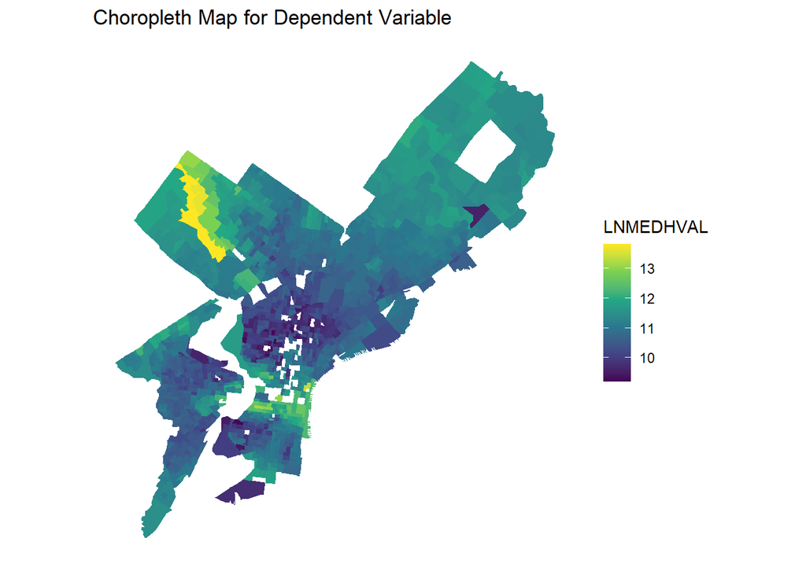

```r
ggplot(sfdata) +
  geom_sf(aes(fill = LNMEDHVAL), color = NA) +
  scale_fill_viridis_c() +
  theme_minimal() +
  theme(panel.grid.major = element_blank(),
      panel.grid.minor = element_blank(), # Remove background grid
      axis.text = element_blank(), axis.ticks = element_blank(), # Remove axis text and ticks
      axis.title = element_blank()) + # Remove axis titles
  labs(title = "Choropleth Map for Dependent Variable", fill = "LNMEDHVAL")
```

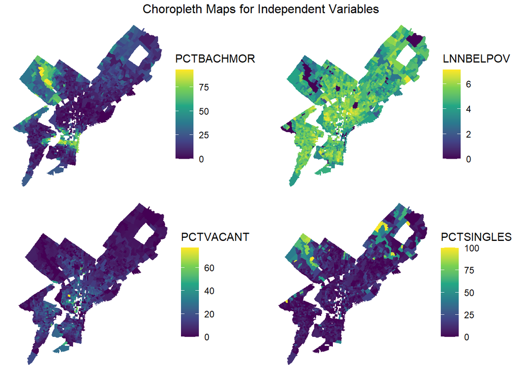

```r
vars_to_plot <- c("PCTBACHMOR", "LNNBELPOV", "PCTVACANT", "PCTSINGLES")

# Create a combined plot
plot_list <- list()
for (var in vars_to_plot) {
  p <- ggplot(sfdata) +
    geom_sf(aes(fill = !!sym(var)), color = NA) + # Use 'sym' from rlang to convert string to symbol
    scale_fill_viridis_c(option = "D") +
    theme_void()
  plot_list[[var]] <- p
}

grid.arrange(grobs = plot_list, ncol = 2, top = "Choropleth Maps for Independent Variables")
```

#### 3.1.4 Correlation Matrix

```
## Correlation computed with
## • Method: 'pearson'
## • Missing treated using: 'pairwise.complete.obs'
```

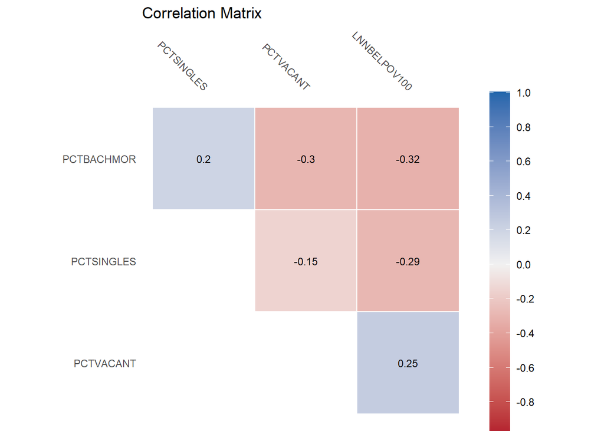

```r
data[c("PCTBACHMOR", "LNNBELPOV100", "PCTVACANT", "PCTSINGLES")] %>%
  correlate() %>%
  autoplot() +
  geom_text(aes(label = round(r, digits=2)), size = 3) +
  labs(title = "Correlation Matrix")
```

### 3.2 Regression Results

We regressed the log-transformed median value of housing units `LNMEDHVAL` on the proportion of residents with at least a bachelor’s degree `PCTBACHMOR`, the log-transformed number of households living in poverty `LNNBELPOV100`, the proportion of vacant housing units `PCTVACANT`, and the percentage of single family houses `PCTSINGLES`. The regression output tells us that all independent variables are statistically significant in explaining the dependent variable with p<0.01. The p-value tells us that if there is actually no relationship between the independent variable and the dependent variable (i.e., if the null hypothesis that β1=0 is actually true), then the probability of getting a coefficient estimate is less than 0.01. These low p-value indicate that we can safely reject H0: $β_{1}$ = 0 for Ha: $β_{1}$ ≠ 0, H0: $β_{2}$ = 0 for Ha: $β_{2}$ ≠ 0, H0: $β_{3}$ = 0 for Ha: $β_{3}$ ≠ 0, and H0: $β_{4}$ = 0 for Ha: $β_{4}$ ≠ 0, (at most reasonable levels of α = P(Type I error)). The percentage of single family houses and the proportion of residents with at least a bachelor’s degree are positively associated with the dependent variable while the log-transformed number of households living in poverty and the proportion of vacant housing units are negatively associated with the dependent variable.

```r
lm = lm(LNMEDHVAL ~ PCTBACHMOR + LNNBELPOV100 + PCTVACANT + PCTSINGLES, data = data)

stargazer(lm, type = "text", title = "Linear Regression", align = TRUE)
```

```
##
## Linear Regression
## ===============================================
##                         Dependent variable:
##                     ---------------------------
##                              LNMEDHVAL
## -----------------------------------------------
## PCTBACHMOR                   0.021***
##                               (0.001)
##
## LNNBELPOV100                 -0.078***
##                               (0.008)
##
## PCTVACANT                    -0.019***
##                               (0.001)
##
## PCTSINGLES                   0.003***
##                               (0.001)
##
## Constant                     11.108***
##                               (0.046)
##
## -----------------------------------------------
## Observations                   1,720
## R2                             0.662
## Adjusted R2                    0.661
## Residual Std. Error      0.367 (df = 1715)
## F Statistic          840.395*** (df = 4; 1715)
## ===============================================
## Note:               *p<0.1; **p<0.05; ***p<0.01
```

Here is the result of error sum of squares for the regression.

```r
anova(lm)
```

```
## Analysis of Variance Table
##
## Response: LNMEDHVAL
##                Df Sum Sq Mean Sq  F value                Pr(>F)
## PCTBACHMOR      1 369.18  369.18 2747.676 < 0.00000000000000022 ***
## LNNBELPOV100    1  27.07   27.07  201.447 < 0.00000000000000022 ***
## PCTVACANT       1  53.03   53.03  394.684 < 0.00000000000000022 ***
## PCTSINGLES      1   2.39    2.39   17.772             0.0000262 ***
## Residuals    1715 230.43    0.13
## ---
## Signif. codes:  0 '***' 0.001 '**' 0.01 '*' 0.05 '.' 0.1 ' ' 1
```

### 3.3 Regression Assumption Checks

In this section, we will be talking about testing model assumptions: linearity, residual normality, homoscedasticity, and spatial autocorrelation. Variables distribution is already discussed in previous section.

#### 3.3.1 Linearity

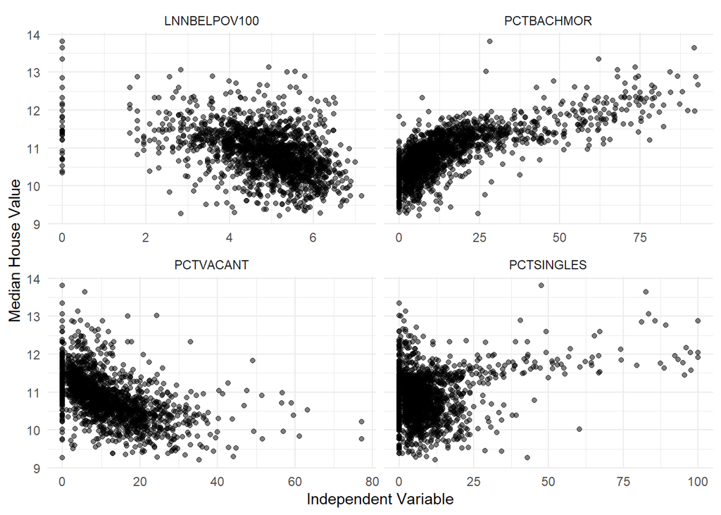

```r
data_long <- reshape2::melt(data, id.vars = 'LNMEDHVAL',
                            measure.vars = c('LNNBELPOV100', 'PCTBACHMOR', 'PCTVACANT', 'PCTSINGLES'))

# Plot using ggplot2 with facet_wrap to create individual plots for each variable
ggplot(data_long, aes(x = value, y = LNMEDHVAL)) +
  geom_point(alpha = 0.5) +
  facet_wrap(~variable, scales = 'free_x') +
  theme_minimal() +
  labs(y = 'Median House Value', x = 'Independent Variable')
```

#### 3.3.2 Residual Normality

To test the second assumption, we will plot the distribution of standardized residuals, which is the raw residual divided by an estimate of the standard deviation of the residuals. The histogram of standardized residuals looks normally distributed.

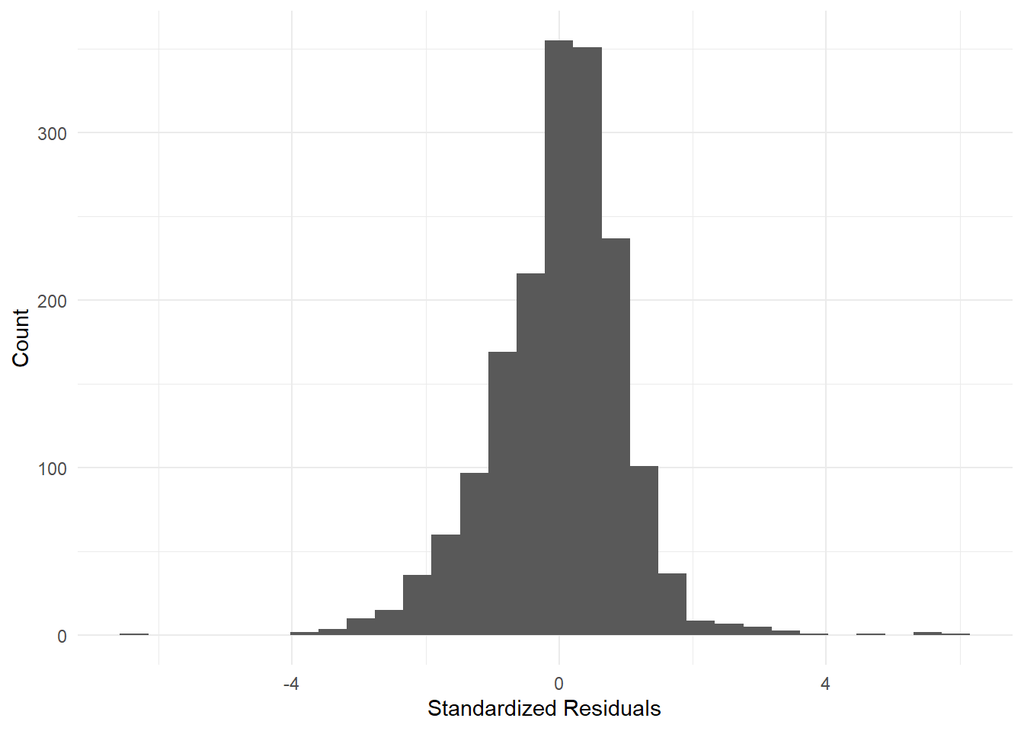

```r
data$predvals <- fitted(lm)
data$resids <- residuals(lm)
data$stdres <- rstandard(lm)

ggplot(data) +
  geom_histogram(aes(x = stdres)) +
  theme_minimal() +
  labs(x = 'Standardized Residuals', y = 'Count')
```

#### 3.3.3 Homoscedasticity

According the the plot of standardized residual by predicted value scatter plot, the variance of residuals seem different at various predicted value, meaning heteroscedasticity.

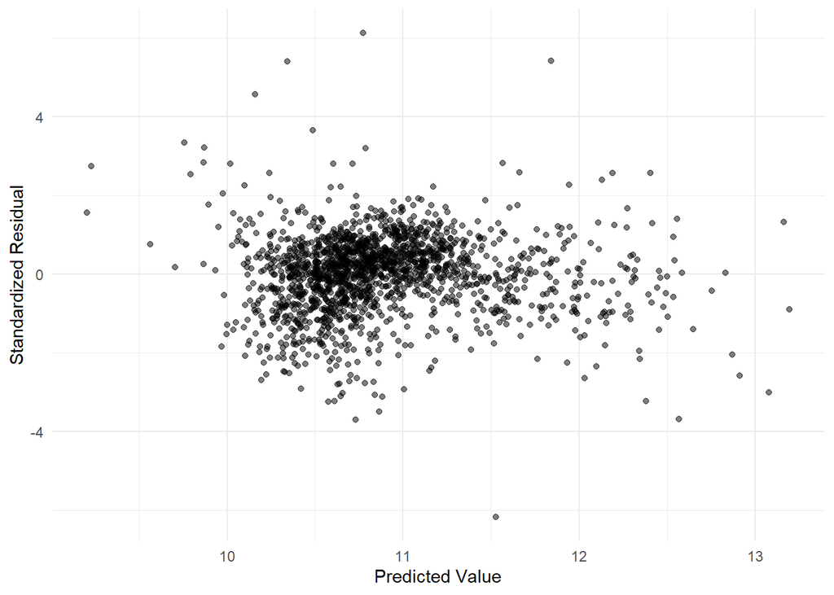

```r
ggplot(data, aes(x = predvals, y = stdres)) +
  geom_point(alpha = 0.5) +
  theme_minimal() +
  labs(y = 'Standardized Residual', x = 'Predicted Value')
```

#### 3.3.4 Spatial autocorrelation

By the choropleth maps we have drawn earlier, block groups that are close together do have similar values, meaning the observations are not spatially independent of each other. The choropleth map of the standardized regression residuals also shows that there are spatial patterns in the standardized residuals, with areas especially high in standardized residuals, indicating spatial autocorrelation.

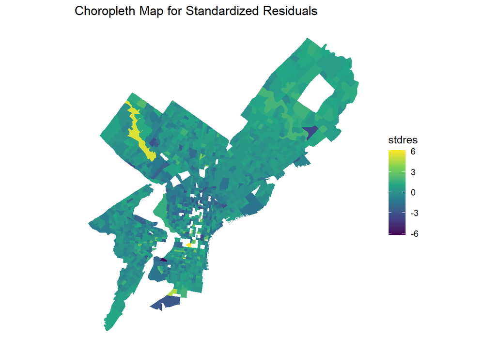

```r
sfdata$stdres <- rstandard(lm)
ggplot(sfdata) +
  geom_sf(aes(fill = stdres), color = NA) +
  scale_fill_viridis_c() +
  theme_minimal() +
  theme(panel.grid.major = element_blank(),
      panel.grid.minor = element_blank(), # Remove background grid
      axis.text = element_blank(), axis.ticks = element_blank(), # Remove axis text and ticks
      axis.title = element_blank()) + # Remove axis titles
  labs(title = "Choropleth Map for Standardized Residuals", fill = "stdres")
```

### 3.4 Additional Models

Stepwise regression could automatically select variables for regression model. Based on the results, all four variables are kept in the final model.

```r
step <- stepAIC(lm, direction="both")
```

```
## Start:  AIC=-3447.45
## LNMEDHVAL ~ PCTBACHMOR + LNNBELPOV100 + PCTVACANT + PCTSINGLES
##
##                Df Sum of Sq    RSS     AIC
## <none>                      230.43 -3447.4
## - PCTSINGLES    1     2.388 232.82 -3431.7
## - LNNBELPOV100  1    11.608 242.04 -3364.9
## - PCTVACANT     1    51.524 281.95 -3102.4
## - PCTBACHMOR    1   198.954 429.38 -2378.9
```

```r
step$anova
```

```
## Stepwise Model Path
## Analysis of Deviance Table
##
## Initial Model:
## LNMEDHVAL ~ PCTBACHMOR + LNNBELPOV100 + PCTVACANT + PCTSINGLES
##
## Final Model:
## LNMEDHVAL ~ PCTBACHMOR + LNNBELPOV100 + PCTVACANT + PCTSINGLES
##
##
##   Step Df Deviance Resid. Df Resid. Dev       AIC
## 1                       1715   230.4274 -3447.447
```

Now, we use cross validation and compare the original model that includes all 4 predictors with the RMSE of the model that only includes `PCTVACANT` and `MEDHHINC` as predictors. The RMSE of the original model is lower and the $R^2$ is also higher, indicating better performance.

```r
set.seed(23)
fitControl <- trainControl(method = "cv", number = 5)
lm.cv <- train(LNMEDHVAL ~ PCTBACHMOR + LNNBELPOV100 + PCTVACANT + PCTSINGLES, data = data,
               method = "lm", trControl = fitControl, na.action = na.pass)
lm.cv
```

```
## Linear Regression
##
## 1720 samples
##    4 predictor
##
## No pre-processing
## Resampling: Cross-Validated (5 fold)
## Summary of sample sizes: 1376, 1376, 1376, 1376, 1376
## Resampling results:
##
##   RMSE       Rsquared   MAE
##   0.3667495  0.6628897  0.2723883
##
## Tuning parameter 'intercept' was held constant at a value of TRUE
```

```r
set.seed(23)
fitControl <- trainControl(method = "cv", number = 5)
lm2.cv <- train(LNMEDHVAL ~ MEDHHINC + PCTVACANT, data = data,
               method = "lm", trControl = fitControl, na.action = na.pass)
lm2.cv
```

```
## Linear Regression
##
## 1720 samples
##    2 predictor
##
## No pre-processing
## Resampling: Cross-Validated (5 fold)
## Summary of sample sizes: 1376, 1376, 1376, 1376, 1376
## Resampling results:
##
##   RMSE       Rsquared   MAE
##   0.4426419  0.5078584  0.3174856
##
## Tuning parameter 'intercept' was held constant at a value of TRUE
```

## 4 Discussion and Limitations

In this paper, we explored the relationship between median house values in Philadelphia and various neighborhood characteristics. Our findings from the regression analysis indicate that all the selected predictors—percentage of individuals with Bachelor’s degrees or higher, percentage of vacant houses, number of households living in poverty, and percentage of single-family housing units—have significant associations with the median house values.

Regarding the model’s limitations, certain assumptions of regression were not fully met. For instance, the assumption of homoscedasticity was violated, indicating heteroscedasticity in the data. This could potentially affect the reliability of our parameter estimates. Additionally, we observed spatial autocorrelation in the residuals, which implies that our assumption of independence may not hold true across all observations. The use of the raw number of households living in poverty (NBELPOV100) as a predictor, instead of a percentage, presents another limitation, as it does not account for the scale of the block groups. This could skew the results where larger block groups with more households are concerned.

Considering the potential limitations of our current model, Ridge or LASSO regression could be suitable alternatives. Ridge regression adds a penalty equivalent to the square of the magnitude of coefficients, which can reduce overfitting and multicollinearity. LASSO regression, on the other hand, adds a penalty equivalent to the absolute value of the magnitude of coefficients, which can lead to some coefficients being exactly zero, hence performing variable selection. These methods are particularly useful when there is a risk of overfitting or when the predictors are highly correlated. However, these methods also introduce bias into the parameter estimates, which is the trade-off for reducing variance and avoiding overfitting. In our case, given the multicollinearity was not severe and the model showed good predictive power, the need for these methods is not immediate but could be explored in future research.

Overall, our model shows promising results, but further research could explore alternative regression methods and additional predictors to potentially enhance the model’s performance and address its current limitations.

## Citations:

1 Shlay, Anne & Whitman, Gordon. (2006). Research for Democracy: Linking Community Organizing and Research to Leverage Blight Policy. City & Community. 5. 153 - 171. 10.1111/j.1540-6040.2006.00167.

2 Chetty R, Hendren N, Katz LF. The Effects of Exposure to Better Neighborhoods on Children: New Evidence from the Moving to Opportunity Experiment. Am Econ Rev. 2016 Apr;106(4):855-902. doi: 10.1257/aer.20150572. PMID: 29546974.

3 Urban blight and public health. (2017, April 11). Urban Institute. https://www.urban.org/research/publication/urban-blight-and-public-health

4 Gyourko, Joseph, and Raven Molloy. “Regulation and the high cost of housing in California.” Brookings Papers on Economic Activity. Economic Studies Program, The Brookings Institution, 2015.